# mvgam case study 2: multivariate models

Nicholas Clark (n.clark@uq.edu.au)

In this example we will examine multivariate forecasting models using `mvgam`, which fits GAMs using MCMC sampling via the `JAGS` software (Note that `JAGS` 4.3.0 is required; installation links are found [here](https://sourceforge.net/projects/mcmc-jags/files/)). First a simulation experiment to determine whether `mvgam`'s inclusion of complexity penalisation works by reducing the number of un-needed dynamic factors. In any factor model, choosing the appropriate number of factors `K` can be difficult. The approach used by `mvgam` is to estimate a penalty for each factor that squeezes the factor's variance toward zero, effectively forcing the factor to evolve as a flat white noise process. By allowing each factor's penalty to be estimated in an exponentially increasing manner (following Welty, Leah J., et al. Bayesian distributed lag models: estimating effects of particulate matter air pollution on daily mortality Biometrics 65.1 (2009): 282-291), we hope that we can guard against specying too large a `K`. But we should test this property to see how it behaves in different scenarios. Begin by simulating `8` series that evolve with a shared seasonal pattern and that depend on `2` latent random walk factors. Each series is `100` time steps long, with a seasonal frequency of `12`. We give the trend moderate importance by setting `trend_rel = 0.6` and we allow each series' observation process to be drawn from slightly different Negative Binomial distributions

```r
set.seed(100)
library(mvgam)
dat <- sim_mvgam(T = 100, n_series = 8, n_trends = 2,
    mu_obs = runif(8, 2, 6), size_obs = runif(8,
        0.5, 2), trend_rel = 0.6, train_prop = 0.8)
```

Have a look at the series

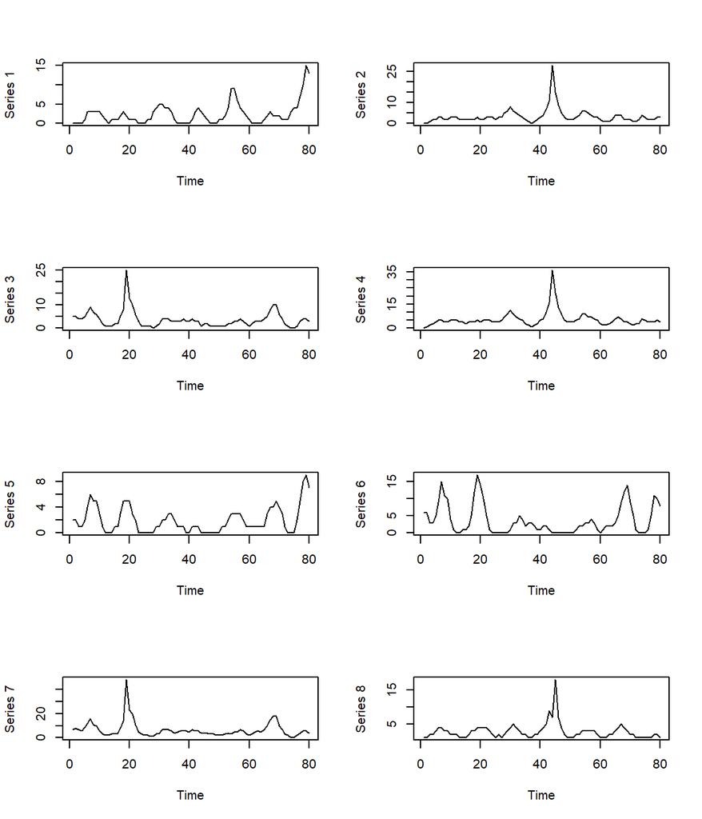

```r
par(mfrow = c(4, 2))
for (i in 1:8) {
    plot(dat$data_train$y[which(as.numeric(dat$data_train$series) ==
        i)], type = "l", ylab = paste("Series",
        i), xlab = "Time")
}
```

```r
par(mfrow = c(1, 1))
```

Clearly there are some correlations in the trends for these series. Now let's fit a well-specified model in which we estimate random intercepts, a shared seasonal cyclic smooth and `2` latent dynamic factors

```r
mod1 <- mvjagam(data_train = dat$data_train,
    data_test = dat$data_test, formula = y ~
        s(series, bs = "re") + s(season,
            bs = c("cc"), k = 12), knots = list(season = c(0.5,
        12.5)), use_lv = T, n_lv = 2, family = "nb",
    trend_model = "RW", chains = 4, burnin = 2000)
```

```
## Fitting a multivariate GAM with latent dynamic factors for the trends...
## Compiling rjags model...
## Starting 4 rjags simulations using a PSOCK cluster with 4 nodes on host
## 'localhost'
## Simulation complete
## Note: Summary statistics were not produced as there are >50 monitored
## variables
## [To override this behaviour see ?add.summary and ?runjags.options]
## FALSEFinished running the simulation
## NOTE: Stopping adaptation
```

Look at a few plots. The estimated smooth function

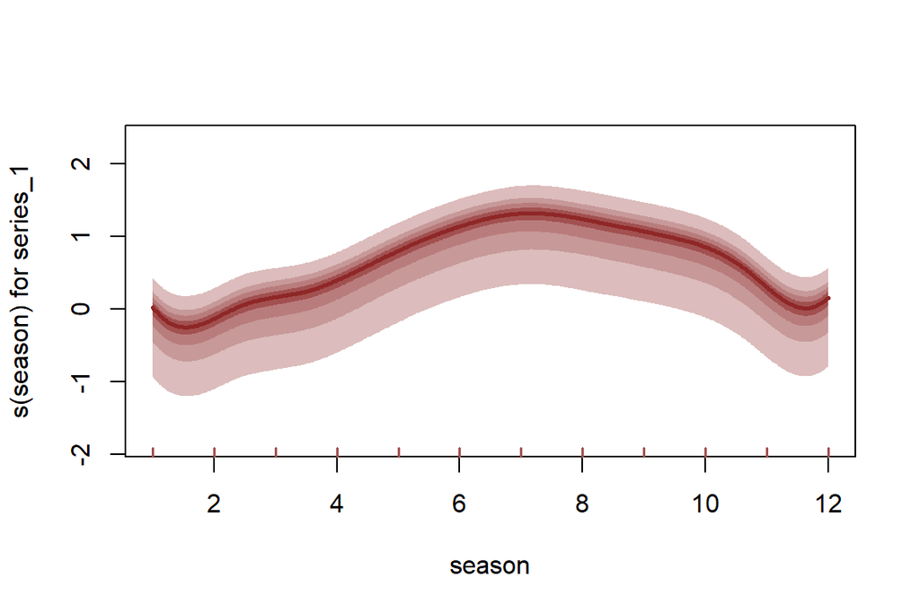

```r
plot_mvgam_smooth(object = mod1, series = 1,
    smooth = "season")
```

And the true seasonal function in the simulation

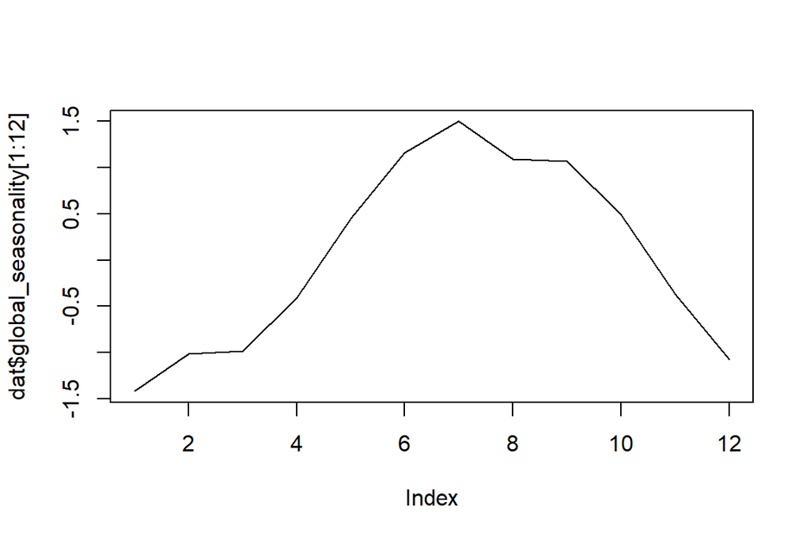

```r
plot(dat$global_seasonality[1:12], type = "l")
```

Check whether each factor was retained using the `plot_mvgam_factors` function. Here, each factor is tested against a null hypothesis of white noise by calculating the sum of the factor's 1st derivatives. A factor that has a larger contribution to the series' latent trends will have a larger sum, both because that factor's absolute magnitudes will be larger (due to the weaker penalty on the factor's precision) and because the factor will move around more. By normalising these estimated first derivative sums, it should be apparent whether some factors have been dropped from the model. Here we see that each factor is contributing to the series' latent trends, and the plots show that neither has been forced to evolve as white noise

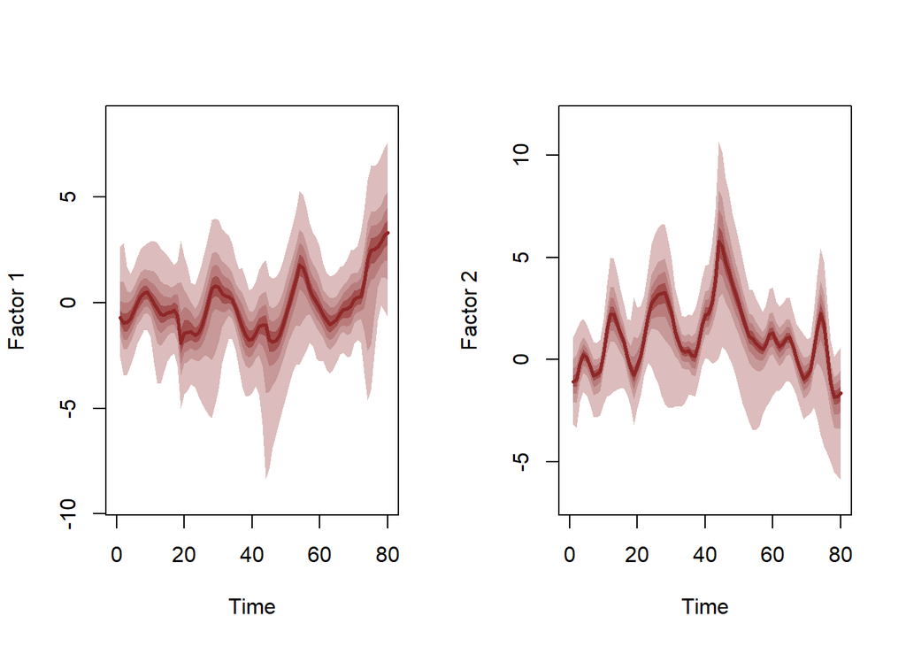

|  | Contribution |
| --- | --- |
| Factor1 | 0.3758443 |
| Factor2 | 0.6241557 |

```r
plot_mvgam_factors(mod1)
```

Now we fit the same model but assume that we no nothing about how many factors to use, so we specify the maximum allowed (the total number of series; `8`). Note that this model is computationally more expensive so it will take longer to fit

```r
mod2 <- mvjagam(data_train = dat$data_train,
    data_test = dat$data_test, formula = y ~
        s(series, bs = "re") + s(season,
            bs = c("cc"), k = 12), knots = list(season = c(0.5,
        12.5)), use_lv = T, n_lv = 8, family = "nb",
    trend_model = "RW", chains = 4, burnin = 2000)
```

```
## Fitting a multivariate GAM with latent dynamic factors for the trends...
## Compiling rjags model...
## Starting 4 rjags simulations using a PSOCK cluster with 4 nodes on host
## 'localhost'
## Simulation complete
## Note: Summary statistics were not produced as there are >50 monitored
## variables
## [To override this behaviour see ?add.summary and ?runjags.options]
## FALSEFinished running the simulation
## NOTE: Stopping adaptation
```

The same plots as model 1 to see if this model has also fit the data well

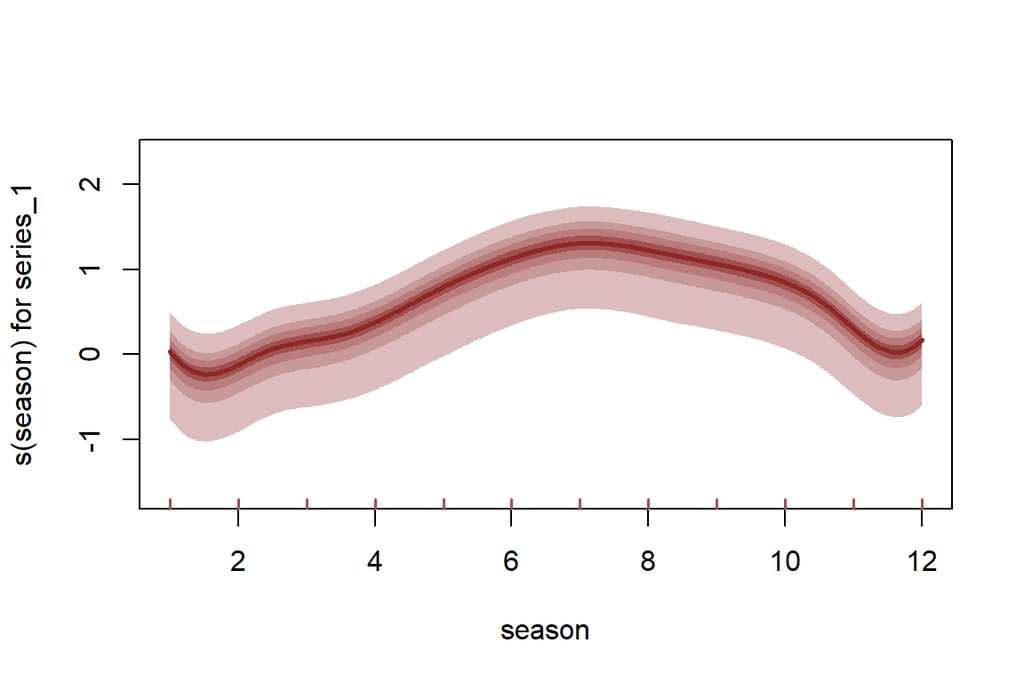

```r
plot_mvgam_smooth(object = mod2, series = 1,
    smooth = "season")
```

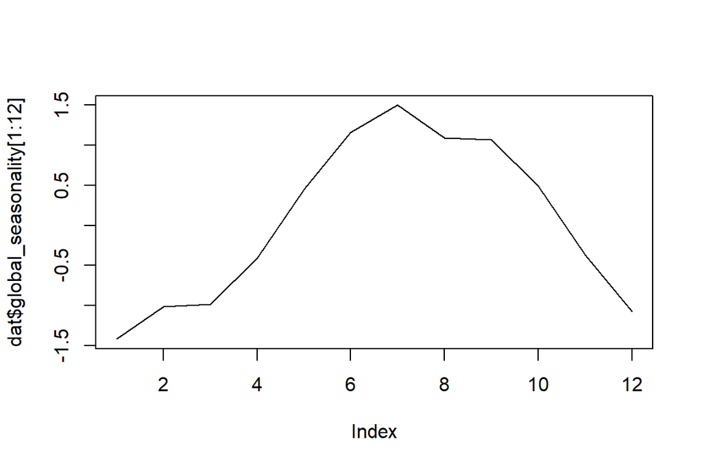

```r
plot(dat$global_seasonality[1:12], type = "l")
```

Examining the factor contributions gives us some insight into whether we set `n_lv` larger than we perhaps needed to. These contributions can be interpreted similarly to ordination axes when deciding how many latent variables to specify

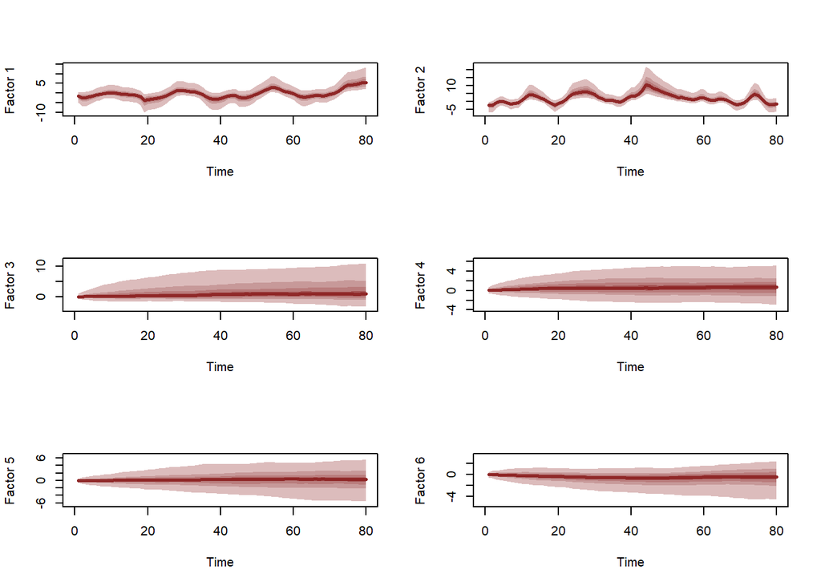

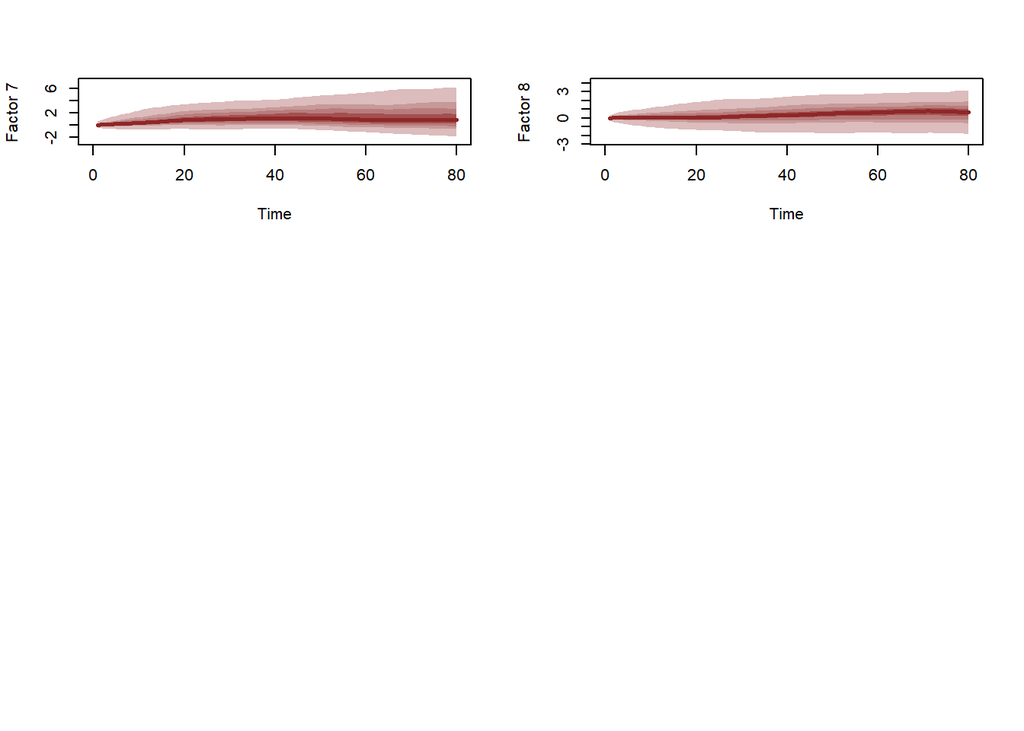

|  | Contribution |
| --- | --- |
| Factor1 | 0.25711476 |
| Factor2 | 0.58183107 |
| Factor3 | 0.04958668 |
| Factor4 | 0.02640047 |
| Factor5 | 0.02788707 |
| Factor6 | 0.01320176 |
| Factor7 | 0.02880085 |
| Factor8 | 0.01517736 |

```r
plot_mvgam_factors(mod2)
```

The very weak contributions by some of the factors are a result of the penalisation, which will become more important as the dimensionality of the data grows. Now onto an empirical example. Here we will access monthly search volume data from `Google Trends`, focusing on relative importances of search terms related to tick paralysis in Queensland, Australia

```r
library(mvgam)
library(tidyr)
if (!require(gtrendsR)) {
    install.packages("gtrendsR")
}

terms = c("tick bite", "tick paralysis",
    "dog tick", "paralysis tick dog")
trends <- gtrendsR::gtrends(terms, geo = "AU-QLD",
    time = "all", onlyInterest = T)
```

`Google Trends` modified their algorithm for extracting search volume data in 2012, so we filter the series to only include observations after this point in time

```r
gtest <- trends$interest_over_time %>% tidyr::spread(keyword,
    hits) %>% dplyr::select(-geo, -time,
    -gprop, -category) %>% dplyr::mutate(date = lubridate::ymd(date)) %>%
    dplyr::mutate(year = lubridate::year(date)) %>%
    dplyr::filter(year > 2012) %>% dplyr::select(-year)
```

Convert to an `xts` object and then to the required `mvgam` format, holding out the final 10% of observations as the test data

```r
series <- xts::xts(x = gtest[, -1], order.by = gtest$date)
trends_data <- series_to_mvgam(series, freq = 12,
    train_prop = 0.9)
```

Plot the series to see how similar their seasonal shapes are over time

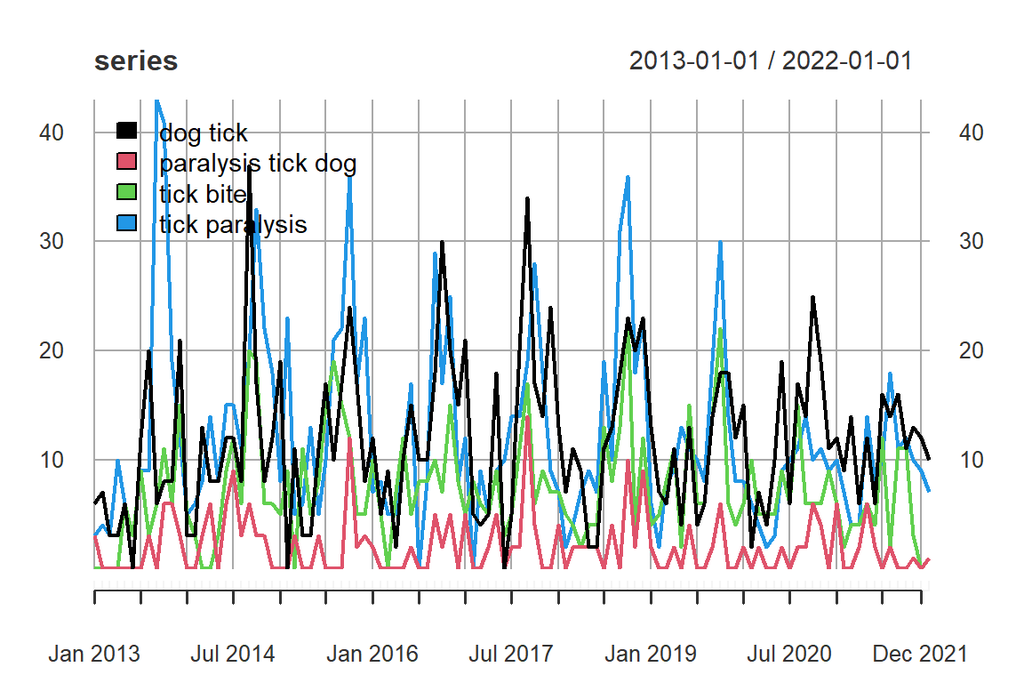

```r
plot(series, legend.loc = "topleft")
```

Now we will fit an `mvgam` model with shared seasonality and random intercepts per series. Our first attempt will ignore any temporal component in the residuals so that we can identidy which GAM predictor combination gives us the best fit, prior to investigating how to deal with any remaining autocorrelation. We assume a Negative Binomial distrubution with series-specific overdispersion parameters for the response. We use a complexity-penalising prior for the overdispersion, which allows the model to reduce toward a more simple Poisson observation process unless the data provide adequate information to support overdispersion. Also note that any smooths using the random effects basis (`s(series, bs = "re")` below) are automatically re-parameterised to use the [non-centred parameterisation that is necessary to help avoid common posterior degeneracies in hierarchical models](https://betanalpha.github.io/assets/case_studies/hierarchical_modeling.html). We suppress the global intercept as it is not needed and will lead to identifiability issues when estimating the series-specific random intercepts

```r
trends_mod1 <- mvjagam(data_train = trends_data$data_train,
    data_test = trends_data$data_test, formula = y ~
        s(series, bs = "re") + s(season,
            k = 12, m = 2, bs = "cc") - 1,
    knots = list(season = c(0.5, 12.5)),
    trend_model = "None", family = "nb",
    chains = 4, burnin = 8000)
```

```
## Compiling rjags model...
## Starting 4 rjags simulations using a PSOCK cluster with 4 nodes on host
## 'localhost'
## Simulation complete
## Note: Summary statistics were not produced as there are >50 monitored
## variables
## [To override this behaviour see ?add.summary and ?runjags.options]
## FALSEFinished running the simulation
## NOTE: Stopping adaptation
```

Given that these series could potentially be following a hierarchical seasonality, we will also trial a slghtly more complex model with an extra smoothing term per series that allows its seasonal curve to deviate from the global seasonal smooth. Ignore the warning about repeated smooths, as this is not an issue for estimation.

```r
trends_mod2 <- mvjagam(data_train = trends_data$data_train,
    data_test = trends_data$data_test, formula = y ~
        s(season, k = 12, m = 2, bs = "cc") +
            s(season, series, k = 5, bs = "fs",
                m = 1), knots = list(season = c(0.5,
        12.5)), trend_model = "None", family = "nb",
    chains = 4, burnin = 8000)
```

```
## Compiling rjags model...
## Starting 4 rjags simulations using a PSOCK cluster with 4 nodes on host
## 'localhost'
## Simulation complete
## Note: Summary statistics were not produced as there are >50 monitored
## variables
## [To override this behaviour see ?add.summary and ?runjags.options]
## FALSEFinished running the simulation
## NOTE: Stopping adaptation
```

How can we compare these models to ensure we choose one that performs well and provides useful inferences? Beyond posterior retrodictive and predictive checks, we can take advantage of the fact that `mvgam` fits an `mgcv` model to provide all the necessary penalty matrices, as well as to identify good initial values for smoothing and beta parameters. Because we did not modify this model by adding a trend component (the only modification is that we estimated series-specific overdispersion parameters), we can still inspect the usual `mgcv` model comparison routines

```r
anova(trends_mod1$mgcv_model, trends_mod2$mgcv_model,
    test = "LRT")
```

|  | Resid. Df | Resid. Dev | Df | Deviance | Pr(>Chi) |
| --- | --- | --- | --- | --- | --- |
| 1 | 380.4797 | 2159.160 | NA | NA | NA |
| 2 | 377.0191 | 2156.704 | 3.460655 | 2.45573 | 0.5654322 |

```r
AIC(trends_mod1$mgcv_model, trends_mod2$mgcv_model)
```

|  | df | AIC |
| --- | --- | --- |
| trends_mod1$mgcv_model | 12.25213 | 2183.664 |
| trends_mod2$mgcv_model | 14.81028 | 2186.324 |

```r
summary(trends_mod1$mgcv_model)
```

```
##
## Family: Negative Binomial(4.829)
## Link function: log
##
## Formula:
## y ~ s(series, bs = "re") + s(season, k = 12, m = 2, bs = "cc") -
##     1
##
## Approximate significance of smooth terms:
##             edf Ref.df      F p-value
## s(series) 3.996      4 1194.2  <2e-16 ***
## s(season) 5.712     10  533.6  <2e-16 ***
## ---
## Signif. codes:  0 '***' 0.001 '**' 0.01 '*' 0.05 '.' 0.1 ' ' 1
##
## R-sq.(adj) =    0.6   Deviance explained = 54.6%
## fREML = 607.22  Scale est. = 1         n = 392
```

```r
summary(trends_mod2$mgcv_model)
```

```
##
## Family: Negative Binomial(4.912)
## Link function: log
##
## Formula:
## y ~ s(season, k = 12, m = 2, bs = "cc") + s(season, series, k = 5,
##     bs = "fs", m = 1)
##
## Parametric coefficients:
##             Estimate Std. Error t value Pr(>|t|)
## (Intercept)   1.8548     0.4101   4.523 8.17e-06 ***
## ---
## Signif. codes:  0 '***' 0.001 '**' 0.01 '*' 0.05 '.' 0.1 ' ' 1
##
## Approximate significance of smooth terms:
##                    edf Ref.df     F p-value
## s(season)        5.704     10 16.23  <2e-16 ***
## s(season,series) 4.097     19 18.54  <2e-16 ***
## ---
## Signif. codes:  0 '***' 0.001 '**' 0.01 '*' 0.05 '.' 0.1 ' ' 1
##
## R-sq.(adj) =  0.605   Deviance explained = 54.9%
## fREML = 603.28  Scale est. = 1         n = 392
```

WE can also use `JAGS` routines for interrogating models. Which model minimises in-sample DIC?

```r
runjags::extract(trends_mod1$jags_model,
    "dic")
```

```
## Compiling rjags model and adapting for 1000 iterations...
## Obtaining DIC samples from 2000 iterations...
```

```
## Mean deviance:  2138
## penalty 14.87
## Penalized deviance: 2153
```

```r
runjags::extract(trends_mod2$jags_model,
    "dic")
```

```
## Compiling rjags model and adapting for 1000 iterations...
## Obtaining DIC samples from 2000 iterations...
```

```
## Mean deviance:  2133
## penalty 20.57
## Penalized deviance: 2154
```

Model 1 seems to fit better so far, suggesting that hierarchical seasonality does not give better performance for these series. But a problem with both of the above models is that their forecast uncertainties will not increase into the future, which is not how time series forecasts should behave. Here we fit Model 1 again but specifying a time series model for the latent trends. We assume the dynamic trends can be represented using latent factors that each follow an AR1 process, and we will rely on the exponential penalties to help regularise any un-needed factors by setting `n_lv = 4`

```r
trends_mod3 <- mvjagam(data_train = trends_data$data_train,
    data_test = trends_data$data_test, formula = y ~
        s(series, bs = "re") + s(season,
            k = 12, m = 2, bs = "cc") - 1,
    knots = list(season = c(0.5, 12.5)),
    trend_model = "AR1", use_lv = T, n_lv = 4,
    family = "nb", chains = 4, burnin = 8000)
```

```
## Fitting a multivariate GAM with latent dynamic factors for the trends...
## Compiling rjags model...
## Starting 4 rjags simulations using a PSOCK cluster with 4 nodes on host
## 'localhost'
## Simulation complete
## Note: Summary statistics were not produced as there are >50 monitored
## variables
## [To override this behaviour see ?add.summary and ?runjags.options]
## FALSEFinished running the simulation
## NOTE: Stopping adaptation
```

```r
trends_mod3$model_file
```

```
##   [1] "model {"
##   [2] ""
##   [3] "        ## GAM linear predictor"
##   [4] "        eta <- X %*% b"
##   [5] ""
##   [6] "        ## Mean expectations"
##   [7] "        for (i in 1:n) {"
##   [8] "        for (s in 1:n_series) {"
##   [9] "        mu[i, s] <- exp(eta[ytimes[i, s]] + trend[i, s])"
##  [10] "        }"
##  [11] "        }"
##  [12] ""
##  [13] "        ## Latent factors evolve as time series with penalised precisions;"
##  [14] "        ## the penalty terms force any un-needed factors to evolve as flat lines"
##  [15] "        for(j in 1:n_lv){"
```

[output cut: 129 more lines]

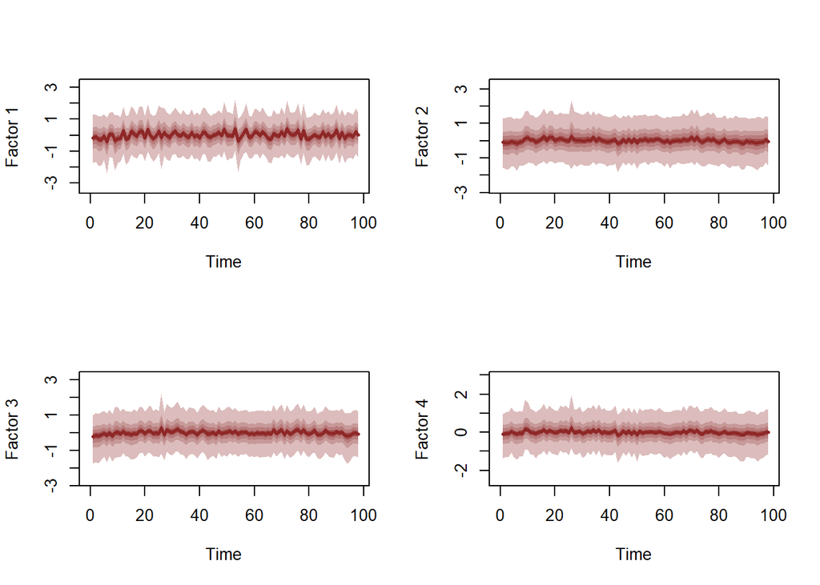

|  | Contribution |
| --- | --- |
| Factor1 | 0.4023147 |
| Factor2 | 0.1642097 |
| Factor3 | 0.2357496 |
| Factor4 | 0.1977260 |

```r
plot_mvgam_factors(trends_mod3)
```

How do forecasts for this model compare to the previous one that did not include any trend component?

```r
compare_mvgams(trends_mod1, trends_mod3,
    fc_horizon = 6, n_cores = 3, n_evaluations = 20)
```

[output not shown]

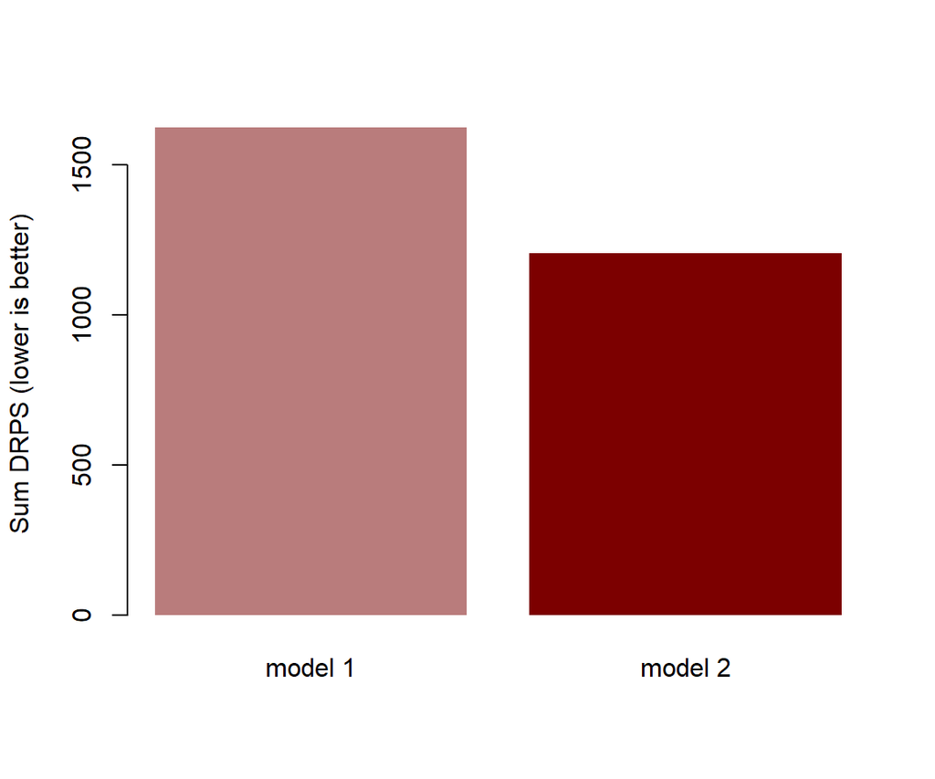

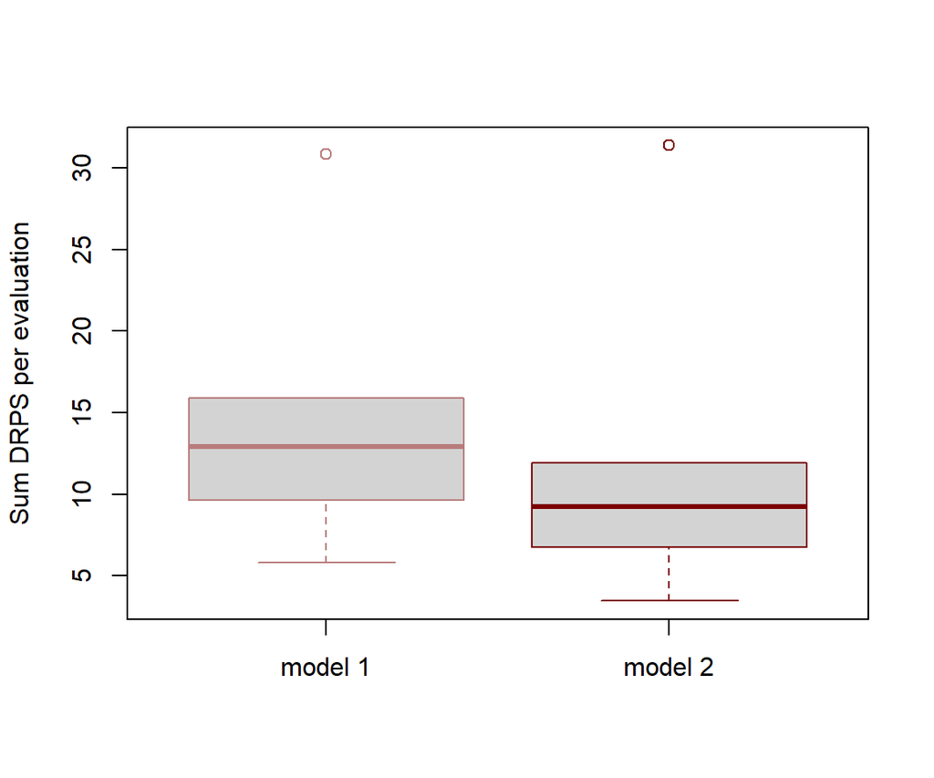

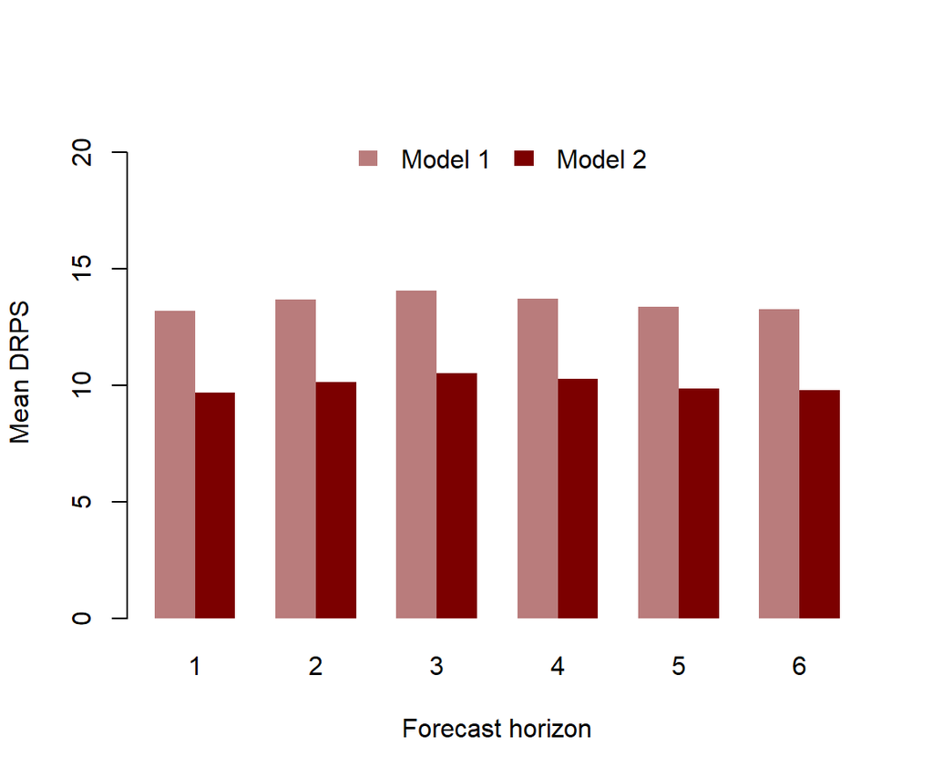

Model 3 (with the dynamic trend) provides far superior forecasts than relying only on the estimated smooths. Inspect the model summary (note again that p-value approximations are a work in progress here and so may not be totally reliable).

```r
summary_mvgam(trends_mod3)
```

```
## GAM formula:
```

```
## y ~ s(series, bs = "re") + s(season, k = 12, m = 2, bs = "cc") -
##     1
```

```
## Family:
```

```
## Negative Binomial
```

```
## N latent factors:
```

```
## 4
```

```
## N series:
```

```
## 4
```

```
## N observations per series:
```

```
## 98
```

```
## Dispersion parameter estimates:
```

```
##           2.5%        50%      97.5% Rhat n.eff
## r[1] 3.3584017  5.5804300  41.596852 1.17  5783
## r[2] 0.4499711  0.7655672   1.712845 1.22  1827
## r[3] 3.0929973  5.6888491  27.317153 1.05  4651
## r[4] 5.0651734 10.2326561 138.094892 1.11  5705
```

```
## GAM smooth term approximate significances:
```

```
##              edf Ref.df      F p-value
## s(series)  3.999  4.000 831.81  <2e-16 ***
## s(season)  6.824 10.000  19.04  <2e-16 ***
## ---
## Signif. codes:  0 '***' 0.001 '**' 0.01 '*' 0.05 '.' 0.1 ' ' 1
```

```
## GAM coefficient (beta) estimates:
```

```
##                     2.5%         50%       97.5% Rhat n.eff
## s(series).1   2.25161814  2.37192720  2.48814851 1.00  2279
## s(series).2   0.28514880  0.60863907  0.90712282 1.00  2189
## s(series).3   1.78364063  1.92803432  2.06067658 1.01  2393
## s(series).4   2.27025820  2.39829491  2.50733730 1.02  1812
## s(season).1  -0.38112106 -0.24595730 -0.11420910 1.01   832
## s(season).2  -0.78453442 -0.58071520 -0.40324507 1.00   551
## s(season).3  -0.72207575 -0.53878642 -0.36014771 1.01   624
## s(season).4  -0.53344796 -0.34992147 -0.17822407 1.00   654
## s(season).5  -0.31621849 -0.14552370  0.02206627 1.00   769
## s(season).6  -0.15291451  0.02440621  0.19703077 1.01   633
## s(season).7   0.15123269  0.33797101  0.52024561 1.01   609
## s(season).8   0.54205552  0.72080789  0.90541571 1.01   588
## s(season).9   0.38081157  0.55161726  0.71413119 1.00   679
## s(season).10  0.08775866  0.22736269  0.36602647 1.00   800
```

```
## GAM smoothing parameter (rho) estimates:
```

```
##                2.5%       50%      97.5% Rhat n.eff
## s(series) -4.869349 -1.716592 -0.1090149    1  7992
## s(season)  4.672467  5.955537  6.9891581    1   969
```

```
## Latent trend drift (phi) and AR parameter estimates:
```

```
##              2.5%         50%     97.5% Rhat n.eff
## phi[1]  0.0000000  0.00000000 0.0000000  NaN     0
## phi[2]  0.0000000  0.00000000 0.0000000  NaN     0
## phi[3]  0.0000000  0.00000000 0.0000000  NaN     0
## phi[4]  0.0000000  0.00000000 0.0000000  NaN     0
## ar1[1] -0.5268512 -0.01852659 0.5489168 1.00  1420
## ar1[2] -0.5316807  0.07457614 0.7712737 1.01   765
## ar1[3] -0.5569900  0.04383589 0.6329749 1.00   953
## ar1[4] -0.5827366  0.02283613 0.6315647 1.00  1092
## ar2[1]  0.0000000  0.00000000 0.0000000  NaN     0
## ar2[2]  0.0000000  0.00000000 0.0000000  NaN     0
## ar2[3]  0.0000000  0.00000000 0.0000000  NaN     0
## ar2[4]  0.0000000  0.00000000 0.0000000  NaN     0
## ar3[1]  0.0000000  0.00000000 0.0000000  NaN     0
## ar3[2]  0.0000000  0.00000000 0.0000000  NaN     0
## ar3[3]  0.0000000  0.00000000 0.0000000  NaN     0
## ar3[4]  0.0000000  0.00000000 0.0000000  NaN     0
```

Look at Dunn-Smyth residuals for some series from this preferred model to ensure that our dynamic factor process has captured most of the temporal dependencies in the observations

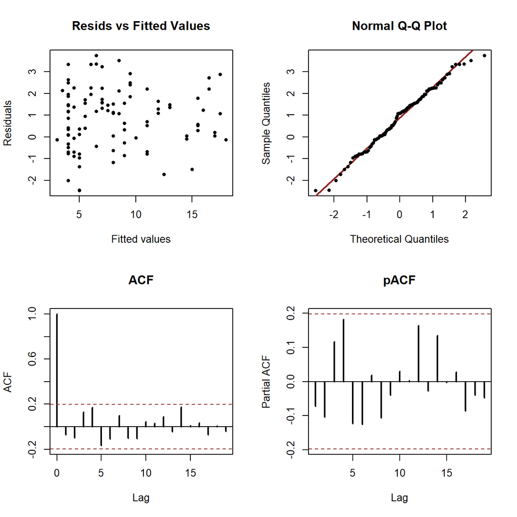

```r
plot_mvgam_resids(trends_mod3, 1)
```

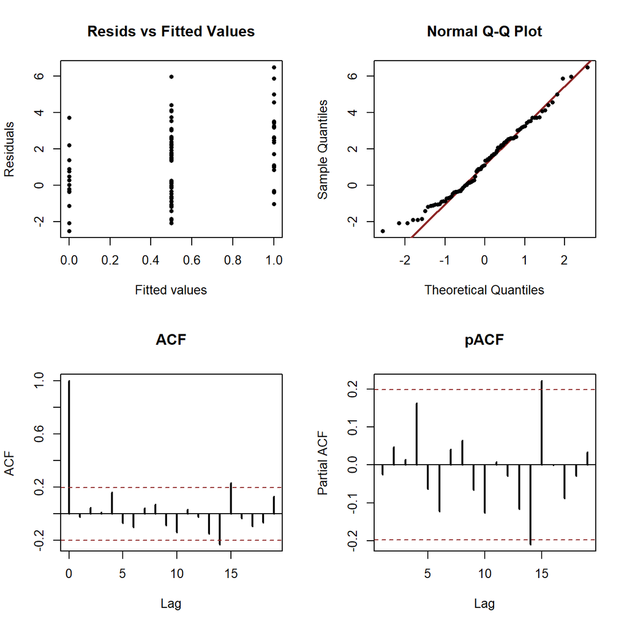

```r
plot_mvgam_resids(trends_mod3, 2)
```

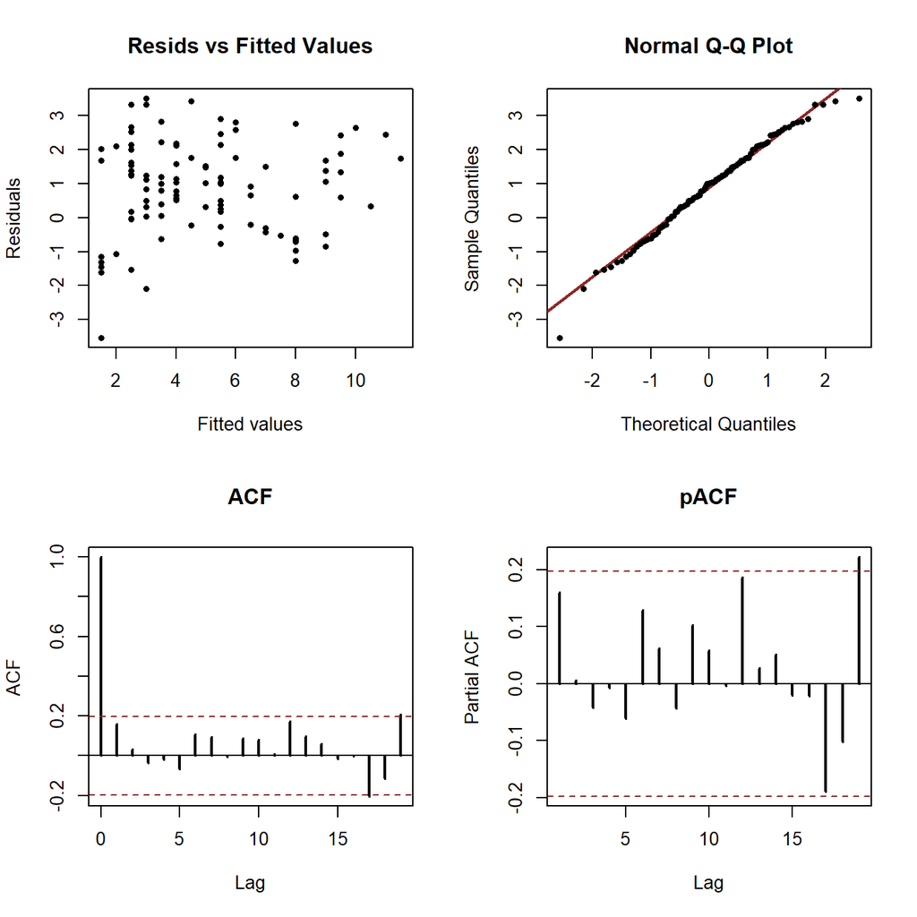

```r
plot_mvgam_resids(trends_mod3, 3)
```

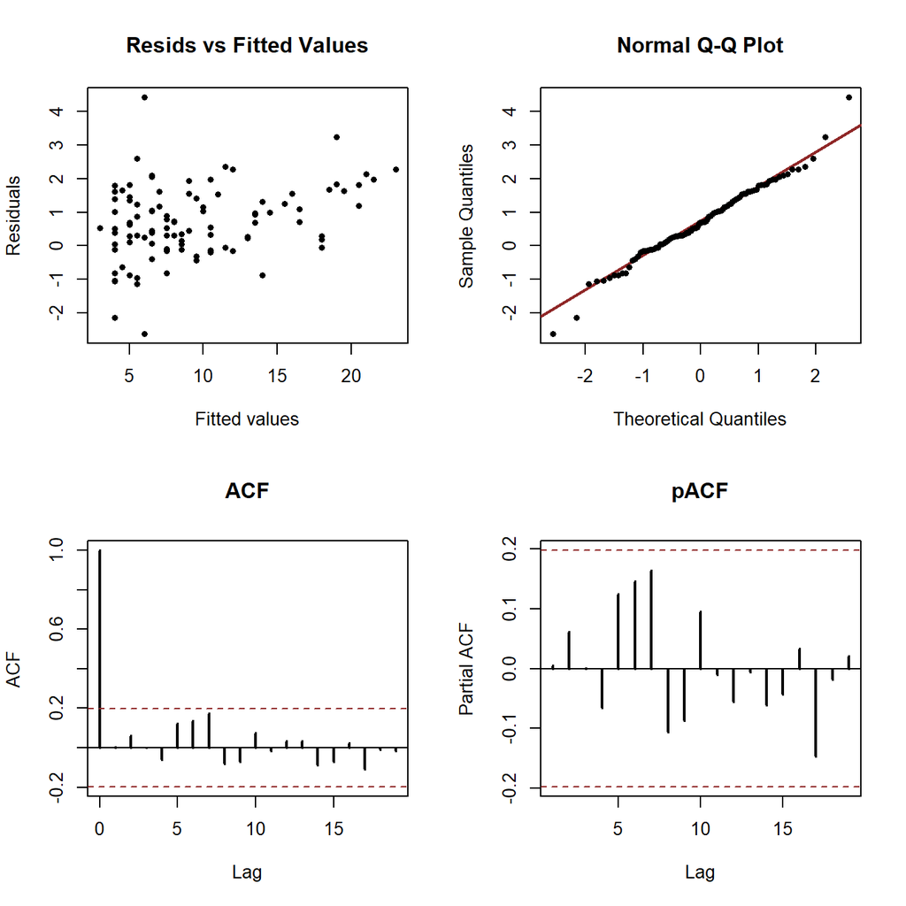

```r
plot_mvgam_resids(trends_mod3, 4)
```

Perform posterior predictive checks to see if the model is able to simulate data that looks realistic and unbiased by examining simulated kernel densities for posterior predictions (`yhat`) compared to the density of the observations (`y`). This will be particularly useful for examining whether the Negative Binomial observation model is able to produce realistic looking simulations for each individual series.

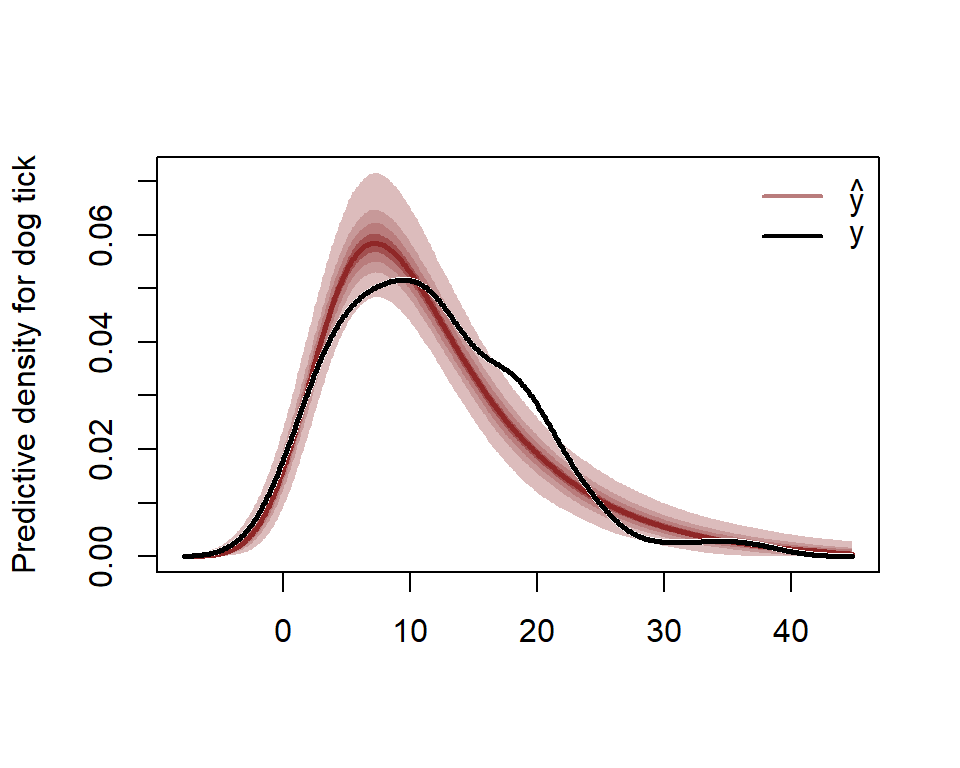

```r
plot_mvgam_ppc(trends_mod3, series = 1, type = "density")
```

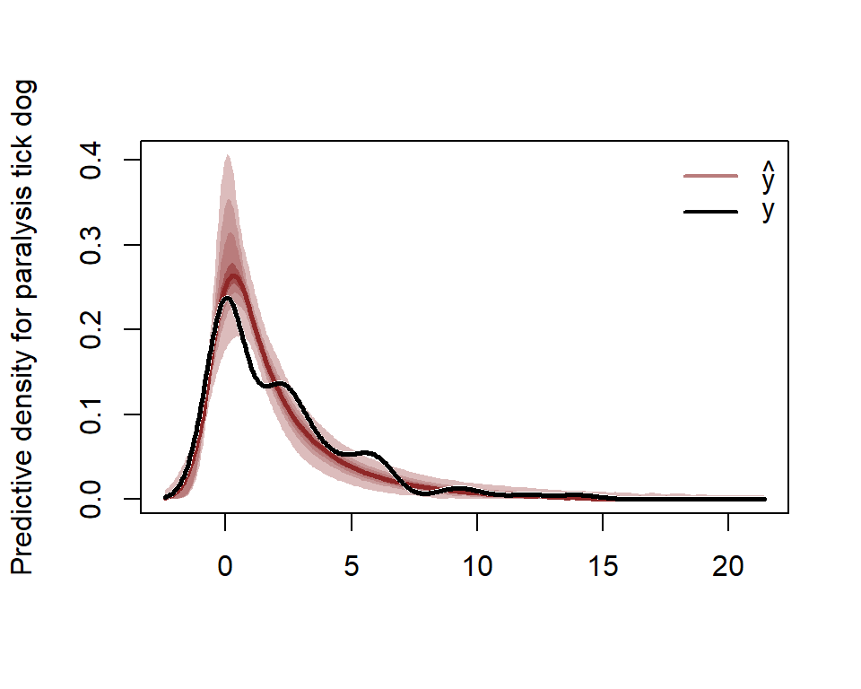

```r
plot_mvgam_ppc(trends_mod3, series = 2, type = "density")
```

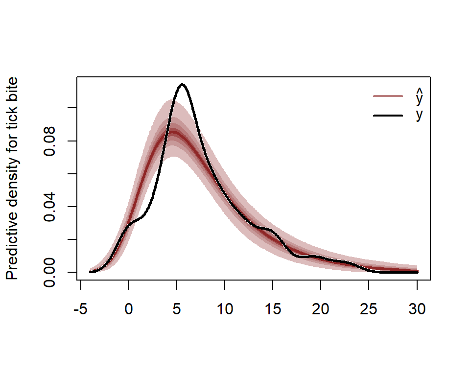

```r
plot_mvgam_ppc(trends_mod3, series = 3, type = "density")
```

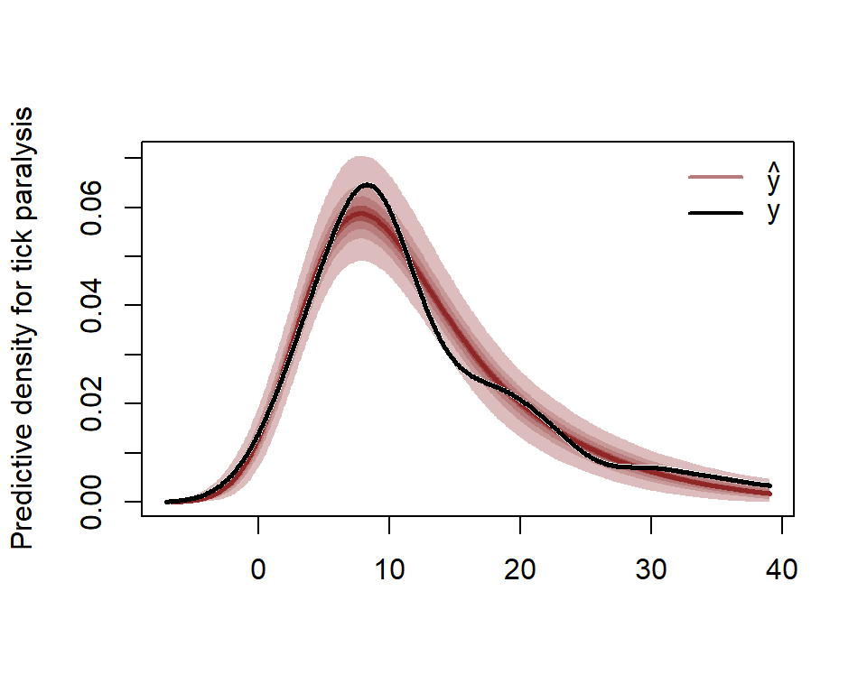

```r
plot_mvgam_ppc(trends_mod3, series = 4, type = "density")
```

Look at traceplots for the smoothing parameters (`rho`)

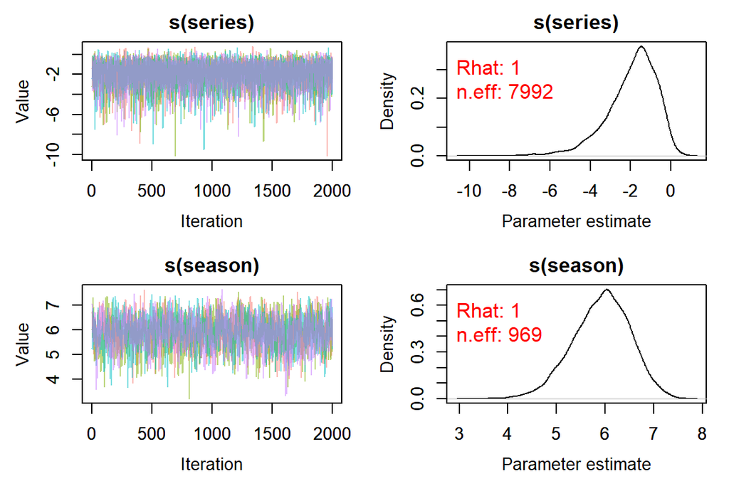

```r
plot_mvgam_trace(object = trends_mod3, param = "rho")
```

Plot posterior predictive distributions for the training and testing periods for each series

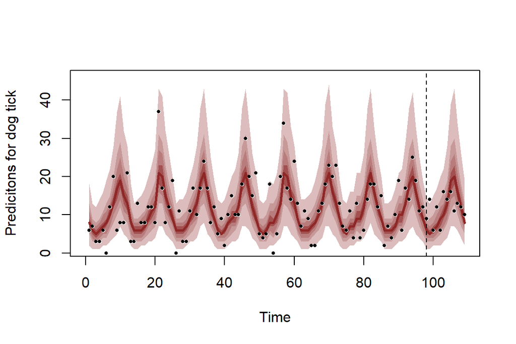

```r
plot_mvgam_fc(object = trends_mod3, series = 1,
    data_test = trends_data$data_test)
```

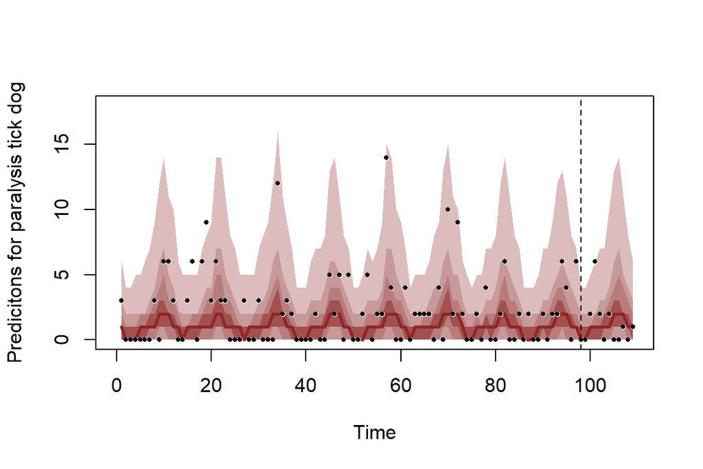

```r
plot_mvgam_fc(object = trends_mod3, series = 2,
    data_test = trends_data$data_test)
```

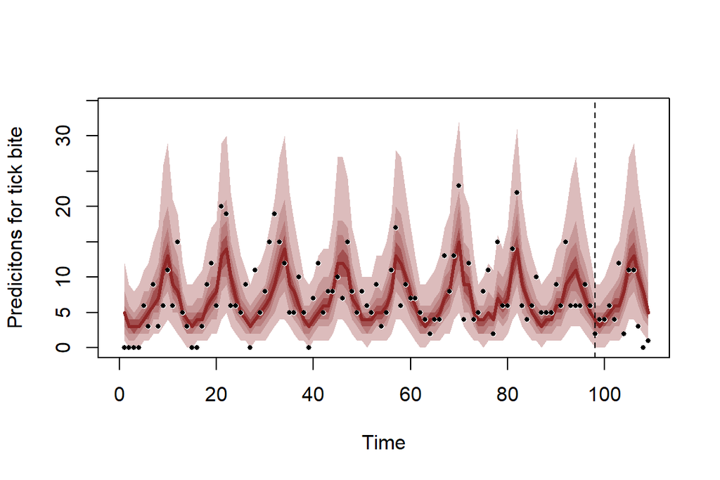

```r
plot_mvgam_fc(object = trends_mod3, series = 3,
    data_test = trends_data$data_test)
```

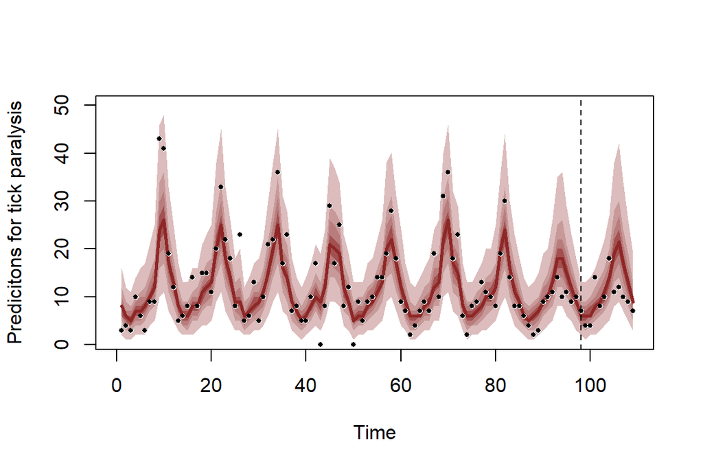

```r
plot_mvgam_fc(object = trends_mod3, series = 4,
    data_test = trends_data$data_test)
```

Plot posterior distributions for the latent trend estimates, again for the training and testing periods

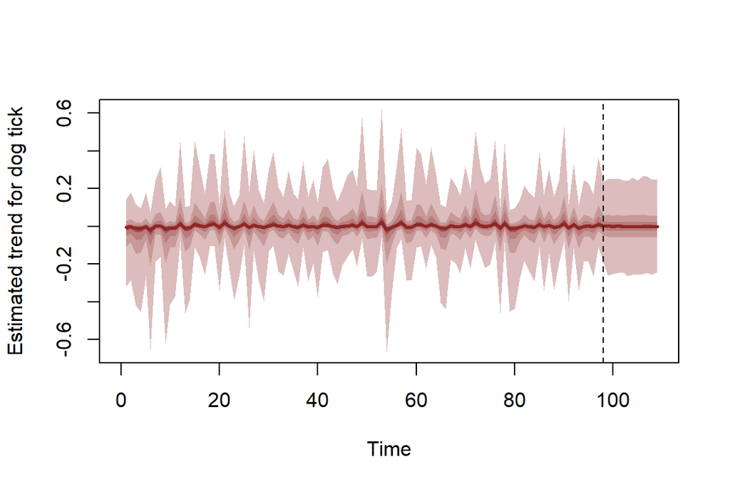

```r
plot_mvgam_trend(object = trends_mod3, series = 1,
    data_test = trends_data$data_test)
```

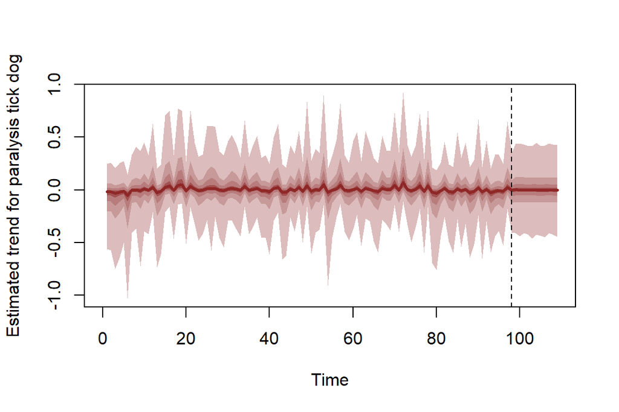

```r
plot_mvgam_trend(object = trends_mod3, series = 2,
    data_test = trends_data$data_test)
```

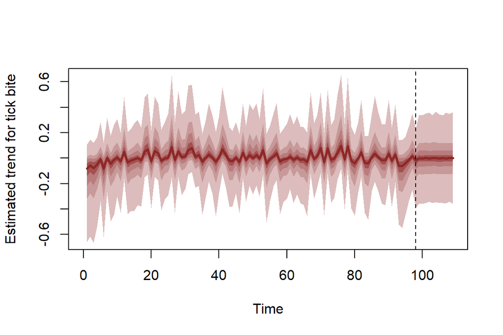

```r
plot_mvgam_trend(object = trends_mod3, series = 3,
    data_test = trends_data$data_test)
```

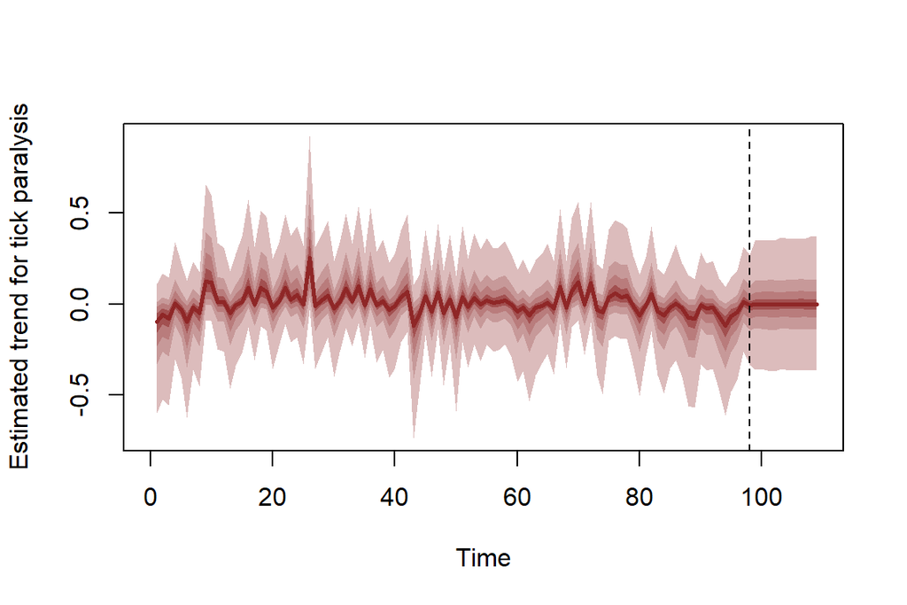

```r
plot_mvgam_trend(object = trends_mod3, series = 4,
    data_test = trends_data$data_test)
```

Given that we fit a model with sharedseasonality, the seasonal smooths will not differ

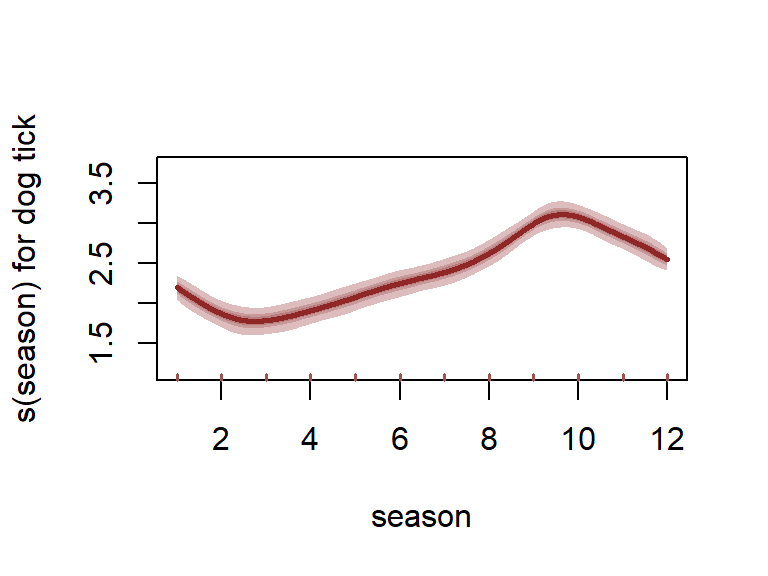

```r
plot_mvgam_smooth(object = trends_mod3, series = 1,
    smooth = "season")
```

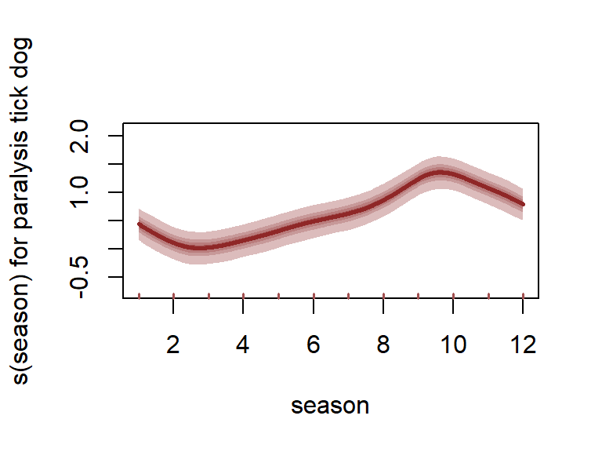

```r
plot_mvgam_smooth(object = trends_mod3, series = 2,
    smooth = "season")
```